# Intro_R

```r
# packages we may need
library(tidyverse)
```

# Data Structure

## Accessing data inside a data frame

Let’s create a data frame called `basket` that contains different kinds of fruits and veggies.

```r
basket <- data.frame(fruits = sample(stringr::fruit, 5), # randomly selecting 5 fruits
                     veggies = c("carrots", "broccoli", "celery", "pepper", "peas"), # 5 kinds of veggies
                     fruit_quantity = c(3, 2, 5, 4, 5), # number of veggies
                     veggie_quantity = c(1, 4, 2, 2, 10)) # number of veggies

# I'm going to save this dataset as my randomly-sampled fruits will be different from yours
# write_csv(basket, here::here("dataset", "basket.csv"))
```

### Indexing

We can use a square bracket (i.e., []) to access an element inside a data frame by its location or column names.

#### By location

```
data.frame[i, j]
```

The first element (i.e., *i*) corresponds to the row, and the second (i.e., *j*) corresponds to the column.

|  | col j1 | col j2 | col j3 |
| --- | --- | --- | --- |
| row i1 | [1, 1] | [1, 2] | [1, 3] |
| row i2 | [2, 1] | [2, 2] | [2, 3] |
| row i3 | [3, 1] | [3, 2] | [3, 3] |

```r
basket
```

| fruits | veggies | fruit_quantity | veggie_quantity |
| --- | --- | --- | --- |
| pear | carrots | 3 | 1 |
| breadfruit | broccoli | 2 | 4 |
| blueberry | celery | 5 | 2 |
| chili pepper | pepper | 4 | 2 |
| bell pepper | peas | 5 | 10 |

##### Single elements

For example, we can access the second element in the 2nd column like this:

```r
basket[2, # 2nd row
       2] # 2nd column
```

```
## [1] "broccoli"
```

##### Multiple elements

We can access multiple elements by using a vector (`c()`) inside a bracket, or `:`sign.

```r
basket[c(1, 3), # elements in the first and third rows
       c(2, 3)] # first element in the second row & third element in the third row
```

|  | veggies | fruit_quantity |
| --- | --- | --- |
| 1 | carrots | 3 |
| 3 | celery | 5 |

```r
basket[c(1, 3),
         2:3] # same as c(2, 3)
```

|  | veggies | fruit_quantity |
| --- | --- | --- |
| 1 | carrots | 3 |
| 3 | celery | 5 |

##### Negative index

We can use **negative index** to exclude elements.

```r
basket[-2, -1] # excluding elements in the 2nd row & 1st column
```

|  | veggies | fruit_quantity | veggie_quantity |
| --- | --- | --- | --- |
| 1 | carrots | 3 | 1 |
| 3 | celery | 5 | 2 |
| 4 | pepper | 4 | 2 |
| 5 | peas | 5 | 10 |

```r
basket[-2, 2:3] # excluding elements in the 2nd row & including elements in the 2nd & 3rd columns
```

|  | veggies | fruit_quantity |
| --- | --- | --- |
| 1 | carrots | 3 |
| 3 | celery | 5 |
| 4 | pepper | 4 |
| 5 | peas | 5 |

#### By column name

We can also use column names. All the codes below will access information stored in the *fruit* column.

```r
basket[ , "fruits"]
```

```
## [1] "pear"         "breadfruit"   "blueberry"    "chili pepper" "bell pepper"
```

```r
basket[["fruits"]]
```

```
## [1] "pear"         "breadfruit"   "blueberry"    "chili pepper" "bell pepper"
```

We use the dollar sign (i.e., `$`) to specify a column.

```r
basket$fruits
```

```
## [1] "pear"         "breadfruit"   "blueberry"    "chili pepper" "bell pepper"
```

Try pressing the *Tab* key after typing the `dollar sign`.

#### By conditions

We can also select elements conditionally; that is, we can specify what element we want. R will evaluate the statement and return only those elements that meet the specified condition.

##### Mathematical Annotations

Conditional statements follow the same operations:

| syntax | meaning | example |
| --- | --- | --- |
| `==` | equal to | x == y |
| `!=` | not equal to | x != y |
| `>` | greater than | x > y |
| `<` | less than | x < y |
| `>=` | greater than or equal to | x >= y |
| `<=` | less than or equal to | x <= y |

You can have multiple conditions by using the following operators:

| syntax | meaning | example |
| --- | --- | --- |
| `\|` | or | x == 1 `\|` x == 2 |
| `&` | and | x == 1 & y == 2 |
| `%in%` | testing multiple elements | x %in% c(1, 2) |

A reference list for the operators can be found [here](https://stat.ethz.ch/R-manual/R-devel/library/grDevices/html/plotmath.html) or [R Cookbook Table 2.1](https://rc2e.com/SomeBasics.html#tab:precedence).

For example, let’s say I only want a specific veggie, carrots:

```r
basket$veggies[basket$veggies == "carrots"] # within the fruit column, element named "pear"
```

```
## [1] "carrots"
```

Or, the broccoli and celery:

```r
# using OR (`|`)
basket$veggies[basket$veggies == "broccoli" | basket$veggies == "celery"]
```

```
## [1] "broccoli" "celery"
```

```r
# using %in%
basket$veggies[basket$veggies %in% c("broccoli", "celery")]
```

```
## [1] "broccoli" "celery"
```

Or, a fruit whose quantity exceeds 3.

```r
basket$fruits[basket$fruit_quantity > 3]
```

```
## [1] "blueberry"    "chili pepper" "bell pepper"
```

#### **Exercise 1**

##### Question

```r
# TODO: change the exercise to something without an error
```

Find all the fruits and veggies whose names do not start with the letter “c”.

```r
# your answer here
```

##### Answer

```r
# read-in saved basket dataset for the example
(basket <- readr::read_csv(here::here("dataset", "basket.csv")))
```

| fruits | veggies | fruit_quantity | veggie_quantity |
| --- | --- | --- | --- |
| rock melon | carrots | 3 | 1 |
| cloudberry | broccoli | 2 | 4 |
| guava | celery | 5 | 2 |
| grapefruit | pepper | 4 | 2 |
| lychee | peas | 5 | 10 |

```r
# Finding the names of fruits and veggies whose names do not start with "c" using the startsWith() function.
basket[!startsWith(basket$fruits, "c"), "fruits"]
```

| fruits |
| --- |
| rock melon |
| guava |
| grapefruit |
| lychee |

```r
basket[!startsWith(basket$veggies, "c"), "veggies"]
```

| veggies |
| --- |
| broccoli |
| pepper |
| peas |

```r
startsWith(as.character(basket$fruits), "c")
```

```
## [1] FALSE  TRUE FALSE FALSE FALSE
```

```r
!startsWith(as.character(basket$fruits), "c")
```

```
## [1]  TRUE FALSE  TRUE  TRUE  TRUE
```

```r
basket[ !startsWith( as.character(basket$fruits), "c") , "fruits"]
```

| fruits |
| --- |
| rock melon |
| guava |
| grapefruit |
| lychee |

# Data Manipulation

For the exercises, we will use an example dataset, starwars.

```r
# import the example dataset
starwars <- dplyr::starwars

# I am going to mess up the data for our exercises; Run this code for extra challenge.

starwars <- starwars %>%
  mutate_at(vars("height"), as.character) %>%  # height is now a character variable
  mutate(hair_color = replace(hair_color, is.na(hair_color), 999)) %>%
  mutate(gender = case_when(
    gender == "feminine" ~ 0,
    gender == "masculine" ~ 1,
    TRUE ~ NA_real_))
```

## 1) Data Preparation

Before analyzing your data, make sure your data is *clean*.

Data preparation can involve:

1. making sure your variables have the correct class attributes
- e.g., a numeric variable not coded as character variable
2. observations are correctly coded
- e.g., a question with the 7-point Likert-type scale ranging from 1 to 7 (and not 5 - 11).
3. checking missing data

Let’s first inspect our dataset using `glimpse()` function from the `tibble` package.

```r
tibble::glimpse(starwars)
```

```
## Rows: 87
## Columns: 14
## $ name       <chr> "Luke Skywalker", "C-3PO", "R2-D2", "Darth Vader", "Leia Or…
## $ height     <chr> "172", "167", "96", "202", "150", "178", "165", "97", "183"…
## $ mass       <dbl> 77.0, 75.0, 32.0, 136.0, 49.0, 120.0, 75.0, 32.0, 84.0, 77.…
## $ hair_color <chr> "blond", "999", "999", "none", "brown", "brown, grey", "bro…
## $ skin_color <chr> "fair", "gold", "white, blue", "white", "light", "light", "…
## $ eye_color  <chr> "blue", "yellow", "red", "yellow", "brown", "blue", "blue",…
## $ birth_year <dbl> 19.0, 112.0, 33.0, 41.9, 19.0, 52.0, 47.0, NA, 24.0, 57.0, …
## $ sex        <chr> "male", "none", "none", "male", "female", "male", "female",…
## $ gender     <dbl> 1, 1, 1, 1, 0, 1, 0, 1, 1, 1, 1, 1, 1, 1, 1, 1, 1, 1, 1, 1,…
## $ homeworld  <chr> "Tatooine", "Tatooine", "Naboo", "Tatooine", "Alderaan", "T…
## $ species    <chr> "Human", "Droid", "Droid", "Human", "Human", "Human", "Huma…
## $ films      <list> <"The Empire Strikes Back", "Revenge of the Sith", "Return…
## $ vehicles   <list> <"Snowspeeder", "Imperial Speeder Bike">, <>, <>, <>, "Imp…
## $ starships  <list> <"X-wing", "Imperial shuttle">, <>, <>, "TIE Advanced x1",…
```

You can get the names of the variables by running `names()` or `colnames()`.

```r
names(starwars)
```

```
##  [1] "name"       "height"     "mass"       "hair_color" "skin_color"
##  [6] "eye_color"  "birth_year" "sex"        "gender"     "homeworld"
## [11] "species"    "films"      "vehicles"   "starships"
```

```r
colnames(starwars)
```

```
##  [1] "name"       "height"     "mass"       "hair_color" "skin_color"
##  [6] "eye_color"  "birth_year" "sex"        "gender"     "homeworld"
## [11] "species"    "films"      "vehicles"   "starships"
```

### Class attribute

Make sure your variables have the correct data types.

#### Numeric variables

Make sure our continuous variables (i.e., height and mass) are numeric.

```r
is.numeric(starwars$height)
```

```
## [1] FALSE
```

```r
is.numeric(starwars$mass)
```

```
## [1] TRUE
```

Height variable is not numeirc; convert it to a numeric variable.

```r
starwars$height <- as.numeric(starwars$height)
```

```r
is.numeric(starwars$height)
```

```
## [1] TRUE
```

```r
as.logical(starwars$mass)
```

```
##  [1] TRUE TRUE TRUE TRUE TRUE TRUE TRUE TRUE TRUE TRUE TRUE   NA TRUE TRUE TRUE
## [16] TRUE TRUE TRUE TRUE TRUE TRUE TRUE TRUE TRUE TRUE TRUE   NA   NA TRUE TRUE
## [31] TRUE TRUE   NA TRUE TRUE   NA   NA   NA TRUE   NA   NA TRUE   NA TRUE TRUE
## [46]   NA TRUE TRUE TRUE TRUE   NA TRUE   NA   NA TRUE   NA TRUE   NA   NA TRUE
## [61] TRUE TRUE   NA TRUE   NA TRUE TRUE TRUE TRUE   NA   NA TRUE   NA TRUE   NA
## [76] TRUE TRUE TRUE TRUE TRUE TRUE   NA   NA   NA   NA   NA TRUE
```

```r
is.numeric(starwars$height_numeric)
```

```
## [1] FALSE
```

#### Factors

Categorical variables can have a special class attribute as **factors**. You can specify the levels of factors and specify whether these levels are ordered (i.e., levels are sorted into an increasing order) or unordered.

For example, let’s look at the gender variable in our starwars dataset. We can look at the frequency table by using the `table()` function.

```r
table(starwars$gender)
```

```
##
##  0  1
## 17 66
```

Let’s check if this variable is a factor.

```r
is.factor(starwars$gender)
```

```
## [1] FALSE
```

It isn’t.

When we plot using gender as is, gender is treated as a continuous numeric variable like so:

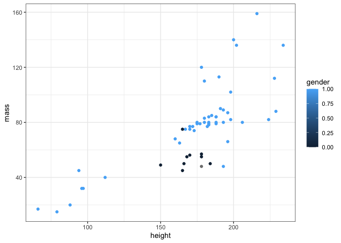

```r
ggplot(subset(starwars, mass < 1000),
       aes(x = height,
           y = mass,
           colour = gender)) +
  geom_point() +
  theme_bw()
```

We can convert the gender variable using the `factor()` function.

```r
starwars$gender <- factor(starwars$gender,
                          levels = c(0:3), # numeric values representing the levels
                          labels = c("female", "male","hermaphrodite", "none"), # corresponding lables for each of the numeric value
                          ordered = FALSE) # change this to TRUE if you want it ordered
```

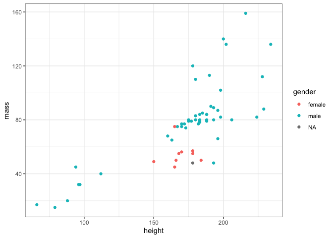

```r
ggplot(subset(starwars, mass < 1000),
       aes(x = height,
           y = mass,
           colour = gender)) +
  geom_point() +
  theme_bw()
```

### Missing data

In R, missing values are coded as `NA`.

Let’s look at characters whose height is missing by running a logical statement, `is.na()`.

```r
head(starwars[is.na(starwars$height)==TRUE, ])
```

| name | height | mass | hair_color | skin_color | eye_color | birth_year | sex | gender | homeworld | species | films | vehicles | starships |
| --- | --- | --- | --- | --- | --- | --- | --- | --- | --- | --- | --- | --- | --- |
| Arvel Crynyd | NA | NA | brown | fair | brown | NA | male | male | NA | Human | Return of the Jedi |  | A-wing |
| Finn | NA | NA | black | dark | dark | NA | male | male | NA | Human | The Force Awakens |  |  |
| Rey | NA | NA | brown | light | hazel | NA | female | female | NA | Human | The Force Awakens |  |  |
| Poe Dameron | NA | NA | brown | light | brown | NA | male | male | NA | Human | The Force Awakens |  | T-70 X-wing fighter |
| BB8 | NA | NA | none | none | black | NA | none | male | NA | Droid | The Force Awakens |  |  |
| Captain Phasma | NA | NA | unknown | unknown | unknown | NA | NA | NA | NA | NA | The Force Awakens |  |  |

We can isolate observations with non-missing height data by negating `is.na()` statement with `!` symbol.

```r
head(starwars[!is.na(starwars$height)==TRUE, ])
```

| name | height | mass | hair_color | skin_color | eye_color | birth_year | sex | gender | homeworld | species | films | vehicles | starships |
| --- | --- | --- | --- | --- | --- | --- | --- | --- | --- | --- | --- | --- | --- |
| Luke Skywalker | 172 | 77 | blond | fair | blue | 19.0 | male | male | Tatooine | Human | The Empire Strikes Back, Revenge of the Sith , Return of the Jedi , A New Hope , The Force Awakens | Snowspeeder , Imperial Speeder Bike | X-wing , Imperial shuttle |
| C-3PO | 167 | 75 | 999 | gold | yellow | 112.0 | none | male | Tatooine | Droid | The Empire Strikes Back, Attack of the Clones , The Phantom Menace , Revenge of the Sith , Return of the Jedi , A New Hope |  |  |
| R2-D2 | 96 | 32 | 999 | white, blue | red | 33.0 | none | male | Naboo | Droid | The Empire Strikes Back, Attack of the Clones , The Phantom Menace , Revenge of the Sith , Return of the Jedi , A New Hope , The Force Awakens |  |  |
| Darth Vader | 202 | 136 | none | white | yellow | 41.9 | male | male | Tatooine | Human | The Empire Strikes Back, Revenge of the Sith , Return of the Jedi , A New Hope |  | TIE Advanced x1 |
| Leia Organa | 150 | 49 | brown | light | brown | 19.0 | female | female | Alderaan | Human | The Empire Strikes Back, Revenge of the Sith , Return of the Jedi , A New Hope , The Force Awakens | Imperial Speeder Bike |  |
| Owen Lars | 178 | 120 | brown, grey | light | blue | 52.0 | male | male | Tatooine | Human | Attack of the Clones, Revenge of the Sith , A New Hope |  |  |

Let’s check the total missing values for each variable by running `colSums()` function.

```r
colSums(is.na(starwars))
```

```
##       name     height       mass hair_color skin_color  eye_color birth_year
##          0          6         28          0          0          0         44
##        sex     gender  homeworld    species      films   vehicles  starships
##          4          4         10          4          0          0          0
```

#### Recode NA

For datasets that use different coding for missing values (e.g., 999), we can convert it to `NA`. In our dataset, missing values for `hair_color` variable are coded as 999; let’s recode this variable.

```r
starwars$hair_color[starwars$hair_color == 999] <- NA
```

#### Dealing with NA

```r
mean(starwars$mass)
```

```
## [1] NA
```

Some functions allow you to specify how NA should be treated with the `na.rm` argument. When you specify `na.rm = TRUE`, missing values (`na`) will be removed (`rm`).

```r
mean(starwars$mass, na.rm = TRUE)
```

```
## [1] 97.31186
```

Alternatively, we can remove any rows that contain missing values using `na.omit()` or `na.exclude()` function.

```r
mean(na.omit(starwars$mass))
```

```
## [1] 97.31186
```

```r
mean(na.exclude(starwars$mass))
```

```
## [1] 97.31186
```

## 2) Data Summary

### Descriptive statistics

Let’s get descriptive statistics of our data. Most often used functions are listed below:

```r
mean(x, na.rm = T) # mean
median(x, na.rm = T) # median
sd(x, na.rm = T) # standard deviation
range(x, na.rm = T) # min and max values
```

### Conditional summary

We can use the indexing techniques to compute summary statistics for the subgroups that meet the qualifications.

For example, we can compute average height of those whose hair colour is brown.

```r
mean(starwars[starwars$hair_color == "brown", ]$height, na.rm = T)
```

```
## [1] 175.2667
```

Characters with brown hair are tad taller than the average height of all the characters, 174.36.

#### **Exercise 2**

##### Question

Within the starwars dataset, find the names of the character whose height falls between the 5th and 95th quantiles.

```r
# your answer here
quantile(starwars$mass,
         probs = c(.05, .95),
         na.rm = T)
```

```
##    5%   95%
##  30.8 136.4
```

##### Answer

```r
# step 1: Find column names
names(starwars)
```

```
##  [1] "name"       "height"     "mass"       "hair_color" "skin_color"
##  [6] "eye_color"  "birth_year" "sex"        "gender"     "homeworld"
## [11] "species"    "films"      "vehicles"   "starships"
```

```r
# step 2: specify what information I want to get: character names
starwars$name
```

```
##  [1] "Luke Skywalker"        "C-3PO"                 "R2-D2"
##  [4] "Darth Vader"           "Leia Organa"           "Owen Lars"
##  [7] "Beru Whitesun lars"    "R5-D4"                 "Biggs Darklighter"
## [10] "Obi-Wan Kenobi"        "Anakin Skywalker"      "Wilhuff Tarkin"
## [13] "Chewbacca"             "Han Solo"              "Greedo"
## [16] "Jabba Desilijic Tiure" "Wedge Antilles"        "Jek Tono Porkins"
## [19] "Yoda"                  "Palpatine"             "Boba Fett"
## [22] "IG-88"                 "Bossk"                 "Lando Calrissian"
## [25] "Lobot"                 "Ackbar"                "Mon Mothma"
## [28] "Arvel Crynyd"          "Wicket Systri Warrick" "Nien Nunb"
## [31] "Qui-Gon Jinn"          "Nute Gunray"           "Finis Valorum"
## [34] "Jar Jar Binks"         "Roos Tarpals"          "Rugor Nass"
## [37] "Ric Olié"              "Watto"                 "Sebulba"
## [40] "Quarsh Panaka"         "Shmi Skywalker"        "Darth Maul"
## [43] "Bib Fortuna"           "Ayla Secura"           "Dud Bolt"
## [46] "Gasgano"               "Ben Quadinaros"        "Mace Windu"
## [49] "Ki-Adi-Mundi"          "Kit Fisto"             "Eeth Koth"
## [52] "Adi Gallia"            "Saesee Tiin"           "Yarael Poof"
## [55] "Plo Koon"              "Mas Amedda"            "Gregar Typho"
## [58] "Cordé"                 "Cliegg Lars"           "Poggle the Lesser"
## [61] "Luminara Unduli"       "Barriss Offee"         "Dormé"
## [64] "Dooku"                 "Bail Prestor Organa"   "Jango Fett"
## [67] "Zam Wesell"            "Dexter Jettster"       "Lama Su"
## [70] "Taun We"               "Jocasta Nu"            "Ratts Tyerell"
## [73] "R4-P17"                "Wat Tambor"            "San Hill"
## [76] "Shaak Ti"              "Grievous"              "Tarfful"
## [79] "Raymus Antilles"       "Sly Moore"             "Tion Medon"
## [82] "Finn"                  "Rey"                   "Poe Dameron"
## [85] "BB8"                   "Captain Phasma"        "Padmé Amidala"
```

```r
# step 3: specify the condition
starwars$height > quantile(starwars$height, 0.05, na.rm = T) # height above the 5th quantile
```

```
##  [1]  TRUE  TRUE FALSE  TRUE  TRUE  TRUE  TRUE  TRUE  TRUE  TRUE  TRUE  TRUE
## [13]  TRUE  TRUE  TRUE  TRUE  TRUE  TRUE FALSE  TRUE  TRUE  TRUE  TRUE  TRUE
## [25]  TRUE  TRUE  TRUE    NA FALSE  TRUE  TRUE  TRUE  TRUE  TRUE  TRUE  TRUE
## [37]  TRUE  TRUE  TRUE  TRUE  TRUE  TRUE  TRUE  TRUE FALSE  TRUE  TRUE  TRUE
## [49]  TRUE  TRUE  TRUE  TRUE  TRUE  TRUE  TRUE  TRUE  TRUE  TRUE  TRUE  TRUE
## [61]  TRUE  TRUE  TRUE  TRUE  TRUE  TRUE  TRUE  TRUE  TRUE  TRUE  TRUE FALSE
## [73] FALSE  TRUE  TRUE  TRUE  TRUE  TRUE  TRUE  TRUE  TRUE    NA    NA    NA
## [85]    NA    NA  TRUE
```

```r
starwars$height < quantile(starwars$height, 0.95, na.rm = T) # height below the 95th quantile
```

```
##  [1]  TRUE  TRUE  TRUE  TRUE  TRUE  TRUE  TRUE  TRUE  TRUE  TRUE  TRUE  TRUE
## [13] FALSE  TRUE  TRUE  TRUE  TRUE  TRUE  TRUE  TRUE  TRUE  TRUE  TRUE  TRUE
## [25]  TRUE  TRUE  TRUE    NA  TRUE  TRUE  TRUE  TRUE  TRUE  TRUE FALSE  TRUE
## [37]  TRUE  TRUE  TRUE  TRUE  TRUE  TRUE  TRUE  TRUE  TRUE  TRUE  TRUE  TRUE
## [49]  TRUE  TRUE  TRUE  TRUE  TRUE FALSE  TRUE  TRUE  TRUE  TRUE  TRUE  TRUE
## [61]  TRUE  TRUE  TRUE  TRUE  TRUE  TRUE  TRUE  TRUE FALSE  TRUE  TRUE  TRUE
## [73]  TRUE  TRUE  TRUE  TRUE  TRUE FALSE  TRUE  TRUE  TRUE    NA    NA    NA
## [85]    NA    NA  TRUE
```

```r
# step 4: combine them!
starwars$name[(starwars$height > quantile(starwars$height, 0.05, na.rm = T)) &
                (starwars$height < quantile(starwars$height, 0.95, na.rm = T))]
```

```
##  [1] "Luke Skywalker"        "C-3PO"                 "Darth Vader"
##  [4] "Leia Organa"           "Owen Lars"             "Beru Whitesun lars"
##  [7] "R5-D4"                 "Biggs Darklighter"     "Obi-Wan Kenobi"
## [10] "Anakin Skywalker"      "Wilhuff Tarkin"        "Han Solo"
## [13] "Greedo"                "Jabba Desilijic Tiure" "Wedge Antilles"
## [16] "Jek Tono Porkins"      "Palpatine"             "Boba Fett"
## [19] "IG-88"                 "Bossk"                 "Lando Calrissian"
## [22] "Lobot"                 "Ackbar"                "Mon Mothma"
## [25] NA                      "Nien Nunb"             "Qui-Gon Jinn"
## [28] "Nute Gunray"           "Finis Valorum"         "Jar Jar Binks"
## [31] "Rugor Nass"            "Ric Olié"              "Watto"
## [34] "Sebulba"               "Quarsh Panaka"         "Shmi Skywalker"
## [37] "Darth Maul"            "Bib Fortuna"           "Ayla Secura"
## [40] "Gasgano"               "Ben Quadinaros"        "Mace Windu"
## [43] "Ki-Adi-Mundi"          "Kit Fisto"             "Eeth Koth"
## [46] "Adi Gallia"            "Saesee Tiin"           "Plo Koon"
## [49] "Mas Amedda"            "Gregar Typho"          "Cordé"
## [52] "Cliegg Lars"           "Poggle the Lesser"     "Luminara Unduli"
## [55] "Barriss Offee"         "Dormé"                 "Dooku"
## [58] "Bail Prestor Organa"   "Jango Fett"            "Zam Wesell"
## [61] "Dexter Jettster"       "Taun We"               "Jocasta Nu"
## [64] "Wat Tambor"            "San Hill"              "Shaak Ti"
## [67] "Grievous"              "Raymus Antilles"       "Sly Moore"
## [70] "Tion Medon"            NA                      NA
## [73] NA                      NA                      NA
## [76] "Padmé Amidala"
```

#### **Exercise 3**

##### Answer

```r
with(starwars, tapply(X = height,
                      INDEX = gender, mean, na.rm = T))
```

```
##        female          male hermaphrodite          none
##      164.6875      176.5161            NA            NA
```

## 3) Data Transformation

Let’s use an example data with participant’s demographic data (i.e., age, gender) and responses to BFI-10 (Rammstedt & John, 2007)

Data codebook here:

| variable name | description | variable name | description |
| --- | --- | --- | --- |
| pid | participant id |  |  |
| age | participant age (in years) |  |  |
| gender | participant gender | BFI_6 | is outgoing, sociable |
| BFI_1 | is reserved | BFI_7 | tends to find fault with others |
| BFI_2 | is generally trusting | BFI_8 | does a thorough job |
| BFI_3 | tends to be lazy | BFI_9 | gets nervous easily |
| BFI_4 | is relaxed | BFI_10 | has an active imagination |
| BFI_5 | has few artistic interests | BFI_11 | handles stress well |

*Note*. “BFI_1”, “BFI_3”, “BFI_4”, and “BFI_5” are reverse-keyed.

```r
# example_data <- readr::read_csv(here::here("dataset", "example_data.csv"))
example_data <- readr::read_csv("https://raw.githubusercontent.com/psy218/r_tutorial/master/dataset/example_data.csv")
```

### Scoring variable

Many functions operate column-wise.

For example, let’s see what happens when we apply `mean(x)` function to conscientiousness items of BFI (i.e., BFI_3 and BFI_8) within the example dataset.

```r
mean(c(example_data$BFI_3, example_data$BFI_8), na.rm = TRUE)
```

```
## [1] 4.020313
```

This returns a single value, the average of everyone’s scores on BFI_3 and BFI_8.

When we need to create an aggregate score for each observation (e.g., participant, row), we need to use the functions that operate row-wise (vs. column-wise): e.g., `rowMeans(x)`, `rowSums(x)`.

We can use `rowMeans(x)` function to create an average of conscientiousness items for each participant.

```r
rowMeans(cbind(example_data$BFI_3, example_data$BFI_8), na.rm = TRUE)
```

```
##   [1] 3.5 2.0 5.0 4.0 3.0 3.5 4.5 4.0 5.0 3.0 4.5 3.0 5.0 3.0 3.5 4.0 4.5 4.5
##  [19] 2.0 5.0 5.0 4.5 4.0 3.0 3.0 4.0 4.5 2.5 3.5 4.0 2.5 2.0 5.0 3.5 3.0 4.0
##  [37] 5.0 4.5 5.0 4.0 4.5 5.0 4.5 4.5 5.0 4.5 2.5 4.5 5.0 4.5 4.0 3.5 4.5 5.0
##  [55] 5.0 3.0 4.5 4.0 4.5 4.0 3.5 5.0 5.0 5.0 4.0 5.0 4.5 5.0 3.5 2.5 4.5 3.0
##  [73] 4.5 5.0 4.5 5.0 4.5 5.0 5.0 2.5 4.5 4.0 5.0 5.0 4.0 4.0 2.5 4.5 3.5 4.0
##  [91] 5.0 5.0 5.0 5.0 3.5 5.0 3.0 5.0 2.5 4.0 3.5 3.5 5.0 2.5 4.0 5.0 3.5 3.5
## [109] 5.0 4.5 5.0 3.5 3.0 5.0 4.0 4.0 3.5 4.0 5.0 3.5 5.0 3.0 4.5 3.0 4.5 5.0
## [127] 5.0 4.0 3.5 5.0 5.0 4.0 4.5 4.0 4.5 5.0 4.0 4.0 4.5 4.0 2.5 3.0 5.0 3.5
## [145] 4.0 4.5 3.0 4.0 5.0 4.5 4.0 5.0 4.0 5.0 3.0 3.5 4.5 2.5 5.0 5.0 3.0 4.5
## [163] 4.0 4.5 5.0 3.0 2.5 3.0 5.0 5.0 2.5 4.0 5.0 3.0 4.0 3.0 4.5 4.0 5.0 3.5
## [181] 4.5 5.0 4.5 5.0 5.0 3.0 5.0 5.0 2.0 2.5 4.5 3.0 5.0 3.0 5.0 5.0 4.0 5.0
## [199] 4.0 5.0 4.0 5.0 5.0 2.0 4.0 5.0 4.5 4.0 4.0 5.0 3.0 5.0 5.0 3.5 4.0 4.5
## [217] 5.0 3.5 5.0 5.0 4.5 4.5 4.5 3.5 3.5 4.0 4.0 4.5 3.5 4.5 4.0 4.0 3.0 3.5
## [235] 2.5 4.5 4.5 3.5 3.0 3.0 5.0 4.5 4.5 5.0 3.5 5.0 2.0 4.0 5.0 3.5 4.0 5.0
## [253] 4.5 3.0 2.5 4.0 3.0 4.5 5.0 5.0 4.0 4.5 4.5 3.5 4.5 4.0 4.0 5.0 4.5 3.5
## [271] 5.0 3.0 2.5 4.0 5.0 2.0 3.5 2.5 3.5 2.0 3.5 3.0 4.5 3.0 3.0 2.5 3.5 4.0
## [289] 5.0 4.0 3.0 4.0 3.0 3.0 1.5 4.5 3.0 5.0 4.0 5.0 5.0 5.0 3.0 2.5 3.5 2.5
## [307] 5.0 5.0 5.0 5.0 1.0 4.0 3.0 3.5 4.0 3.0 3.0 3.5 3.0 5.0
```

For the operations that do not have separate row-wise functions, we can use `apply(x)` function to specify that we want to apply the function row-wise. Specifically, we first define the data we are applying our functions (i.e., `X =`), indicate what function we want to apply (i.e., `FUN =`), and whether we want to apply our function row-wise (i.e., `1`) or column-wise(`2`) in the `MARGIN =` argument.

```r
args(apply)
```

```
## function (X, MARGIN, FUN, ..., simplify = TRUE)
## NULL
```

So instead of using `rowMeans(x)`, the following will yield the same:

```r
apply(cbind(example_data$BFI_3, example_data$BFI_8), 1, mean, na.rm = T)
```

```
##   [1] 3.5 2.0 5.0 4.0 3.0 3.5 4.5 4.0 5.0 3.0 4.5 3.0 5.0 3.0 3.5 4.0 4.5 4.5
##  [19] 2.0 5.0 5.0 4.5 4.0 3.0 3.0 4.0 4.5 2.5 3.5 4.0 2.5 2.0 5.0 3.5 3.0 4.0
##  [37] 5.0 4.5 5.0 4.0 4.5 5.0 4.5 4.5 5.0 4.5 2.5 4.5 5.0 4.5 4.0 3.5 4.5 5.0
##  [55] 5.0 3.0 4.5 4.0 4.5 4.0 3.5 5.0 5.0 5.0 4.0 5.0 4.5 5.0 3.5 2.5 4.5 3.0
##  [73] 4.5 5.0 4.5 5.0 4.5 5.0 5.0 2.5 4.5 4.0 5.0 5.0 4.0 4.0 2.5 4.5 3.5 4.0
##  [91] 5.0 5.0 5.0 5.0 3.5 5.0 3.0 5.0 2.5 4.0 3.5 3.5 5.0 2.5 4.0 5.0 3.5 3.5
## [109] 5.0 4.5 5.0 3.5 3.0 5.0 4.0 4.0 3.5 4.0 5.0 3.5 5.0 3.0 4.5 3.0 4.5 5.0
## [127] 5.0 4.0 3.5 5.0 5.0 4.0 4.5 4.0 4.5 5.0 4.0 4.0 4.5 4.0 2.5 3.0 5.0 3.5
## [145] 4.0 4.5 3.0 4.0 5.0 4.5 4.0 5.0 4.0 5.0 3.0 3.5 4.5 2.5 5.0 5.0 3.0 4.5
## [163] 4.0 4.5 5.0 3.0 2.5 3.0 5.0 5.0 2.5 4.0 5.0 3.0 4.0 3.0 4.5 4.0 5.0 3.5
## [181] 4.5 5.0 4.5 5.0 5.0 3.0 5.0 5.0 2.0 2.5 4.5 3.0 5.0 3.0 5.0 5.0 4.0 5.0
## [199] 4.0 5.0 4.0 5.0 5.0 2.0 4.0 5.0 4.5 4.0 4.0 5.0 3.0 5.0 5.0 3.5 4.0 4.5
## [217] 5.0 3.5 5.0 5.0 4.5 4.5 4.5 3.5 3.5 4.0 4.0 4.5 3.5 4.5 4.0 4.0 3.0 3.5
## [235] 2.5 4.5 4.5 3.5 3.0 3.0 5.0 4.5 4.5 5.0 3.5 5.0 2.0 4.0 5.0 3.5 4.0 5.0
## [253] 4.5 3.0 2.5 4.0 3.0 4.5 5.0 5.0 4.0 4.5 4.5 3.5 4.5 4.0 4.0 5.0 4.5 3.5
## [271] 5.0 3.0 2.5 4.0 5.0 2.0 3.5 2.5 3.5 2.0 3.5 3.0 4.5 3.0 3.0 2.5 3.5 4.0
## [289] 5.0 4.0 3.0 4.0 3.0 3.0 1.5 4.5 3.0 5.0 4.0 5.0 5.0 5.0 3.0 2.5 3.5 2.5
## [307] 5.0 5.0 5.0 5.0 1.0 4.0 3.0 3.5 4.0 3.0 3.0 3.5 3.0 5.0
```

### Reverse-coding

We can reverse-code variables by creating a custom function with two arguments: the maximum value of our scale (`max`) and the variable we want to reverse code (`x`).

```r
# I will name it `reverse_x()`
reverse_x <- function(max, x) {
  (max + 1) - x
}
```

Step 1: Find which items need to be reverse-coded, and store the name into an object.

```r
reverse_keyed_items = paste("BFI", c(1, 3, 4, 5), sep = "_")
```

Step 2: Reverse-code the variables

```r
reverse_coded_bfi <- apply(example_data[ ,reverse_keyed_items], 2, reverse_x, max = 5)
```

Step 3: Merge it into the dataset

```r
reversed_data <- cbind(reverse_coded_bfi, # reverse-coded variables
                       example_data[ -which(names(example_data) %in% reverse_keyed_items)] # original dataset minus items that need to be reverse-coded
)

head(reversed_data)
```

| BFI_1 | BFI_3 | BFI_4 | BFI_5 | pid | age | gender | BFI_2 | BFI_6 | BFI_7 | BFI_8 | BFI_9 | BFI_10 | BFI_11 |
| --- | --- | --- | --- | --- | --- | --- | --- | --- | --- | --- | --- | --- | --- |
| 4 | 3 | 3 | 2 | 1 | 32 | female | 4 | 2 | 2 | 4 | 3 | 4 | 4 |
| 4 | 4 | 5 | 4 | 2 | 31 | female | 5 | 4 | 2 | 2 | 4 | 5 | 1 |
| 1 | 1 | 1 | 1 | 3 | 29 | female | 1 | 5 | 1 | 5 | 1 | 5 | 5 |
| 2 | 2 | 3 | 4 | 4 | 33 | female | 4 | 4 | 3 | 4 | 3 | 3 | 2 |
| 3 | 4 | 5 | 3 | 5 | 29 | male | 4 | 3 | 2 | 4 | 3 | 3 | 1 |
| 4 | 3 | 4 | 3 | 6 | 31 | female | 5 | 5 | 1 | 4 | 4 | 4 | 2 |

Or, just do it at one-go.

```r
reverse_data <- cbind(apply(example_data[ ,paste("BFI", c(1, 3, 4, 5), sep = "_")],
                            2, reverse_x, max = 5),
                      example_data[ -which(names(example_data) %in%
                                             paste("BFI", c(1, 3, 4, 5), sep = "_"))])
```

#### **Exercise 4**

##### Question

Create 1) an aggregate score of `extraversion` for each participant by averaging reverse-coded BFI_1 and BFI_6 and 2) mean-center extraversion score on gender.

##### Answer

```r
#' Step 1a: Reverse-code BFI_1 using `reverse_x()`
#' Step 1b: Create an aggregate score for extroversion using `rowMeans()`

example_data$extraversion <- rowMeans(cbind(reverse_x(5, example_data$BFI_1), # reverse code BFI_1
                                            example_data$BFI_6), # then column-bind with BFI_6
                                      na.rm = T) # compute an average

#' Step 2: Find the average extraversion scores for male and female participants, and save the result as an object (`group_mean`)
group_mean <- with(example_data, tapply(X = extraversion,
                                        INDEX = gender, mean, na.rm = T))

#' Step 3: Calculate mean-centred extraversion score (`extraversion_gc`) by subtracting extraversion score from average extraversion scores (`extraversion`) of men (`group_mean["male"]`) and women (`group_mean["female"]`)
example_data <- within(example_data, {
  extraversion_gc = ifelse(test = gender == "male",
                           yes = extraversion - group_mean["male"],
                           no = extraversion - group_mean["female"])
})
```